# Lectura y escritura de textos filosóficos

## Descripción del curso

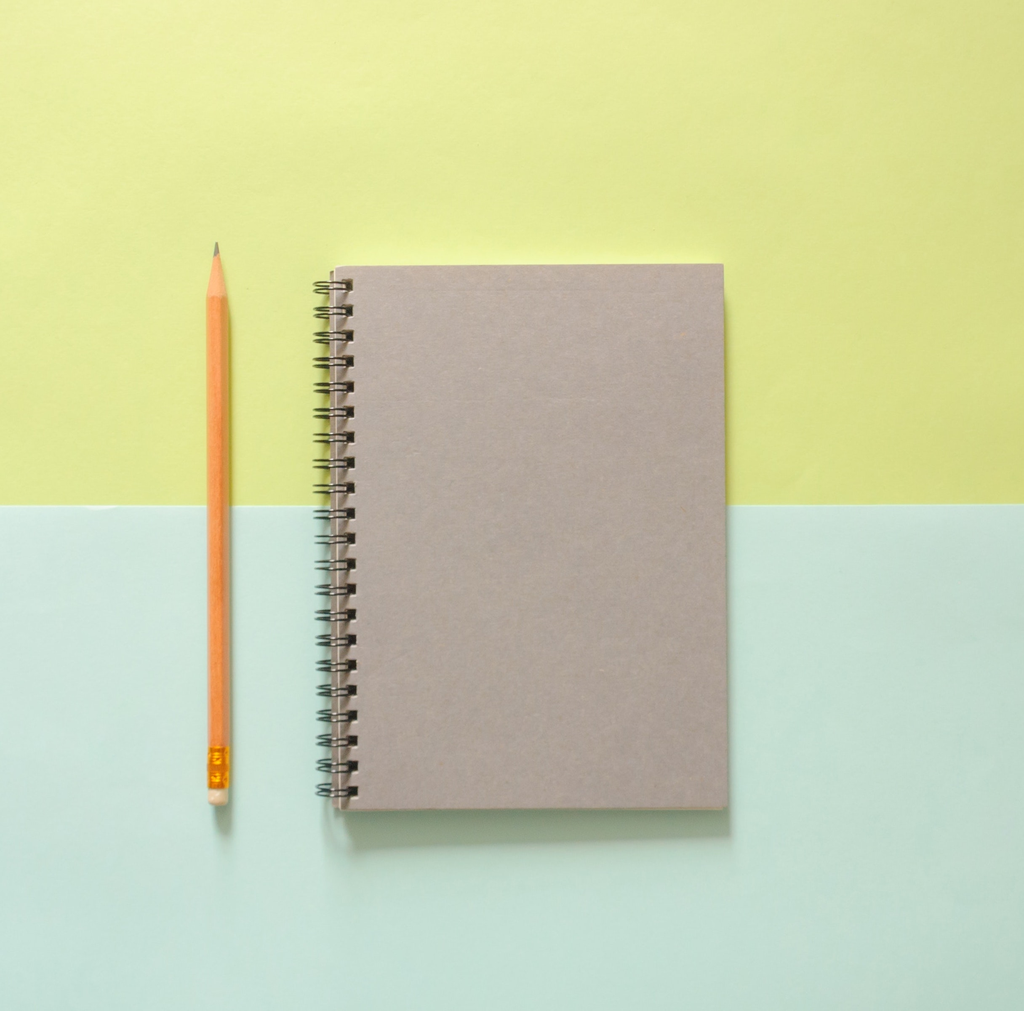

La lectura y escritura de textos filosóficos es la base de la labor filosófica. Este curso es una propedéutica a la escritura y lectura de textos filosóficos. El resto de su carrera en filosofía, puede decirse, consistirá en una profundización y afinamiento de esta herramientas. Para ello, se leerá, discutirá y escribirá sobre tres temas generales: 1) la educación y la lectura, 2) temas particulares en filosofía moral, y 3) temas particulares en filosofía de la mente y otros temas de interés de los estudiantes. Estos temas son una excusa ejercer la lectura y escritura sobre temas filosóficos y nuestro enfoque particular seran las habilidades en lectura y escritura. Se espera que el estudiante logre leer de manera cuidadosa un texto filosófico y que sea capaz de producir reseñas, relatorías, protocolos y ensayos sobre temas propios de la filosofía.

*Docente:* Juan Camilo Espejo-Serna

*Correo electrónico:* juan.espejo1@unisabana.edu.co

*Monitora*: Tatiana Gomez

*Correo electrónico*: tatianagosa@unisabana.edu.co

*Horario y salón:* Lunes 11:00pm - 1:00pm. Atelier 104

*Página web del curso:* http://jcunisabana.github.io/lye

## Objetivos esperados de aprendizaje

1. Identificar el o los puntos principales de un texto y las razones ofrecidas en su favor.
2. Escribir una reseña que dé cuenta de los puntos principales del texto, las razones ofrecidas en su favor y una pequeña evaluación de estos.
3. Escribir una relatoría que dé cuenta de los puntos principales del texto, las razones ofrecidas en su favor y presente preguntas para la discusión en clase.
4. Escribir un protoloco que dé cuenta de los puntos principales del la discusión en clase, dando cuenta de las tesis presentadas y las razones ofrecidas en su favor.
5. Escribir un ensayo que trate un tema filosófico en donde se vea claramente defendida una posición, y se den buenas razones en su favor.
6. Usar adecuadamente el vocabulario y registro propio de la escritura académica.
7. Emplear la gramática, la puntuación y la ortografía adecuada para construir un texto coherente.
8. Usar uno de los diferentes estilos de citación reconocidos en la comunidad académica (APA, Chicago, MLA, etc.) de manera consistente.

## Contenido temático

#### *Módulo 1: Leer y reseñar*

Presentación general del curso

- Hoyos: Filosofía, filosofías, filosofar.
- Nussbaum: Sobre la crisis de la educación.
- Reglas APA, MLA y Chicago

*(5 semanas)*

#### *Módulo 2 - Escribir: Relatorías y protocolos*

Filosofía moral

- Emoción y razón en el juicio moral (Hansberg, Lima)
- Posibilidades alternativas y responsabilidad moral (Frankfurt)
- Razones para actuar (Davidson, Korsgaard)

*(6 semanas)*

#### *Módulo 3 - Escribir: Ensayo argumentativo*

Temas varios

- Pensar lento, pensar rápido (Kahneman)
- Temas seleccionados con base en los intereses de los estudiantes

(*6 semanas*)

## Evaluación

Se evaluará a los estudiantes por medio de trabajos sobre formatos internacionales de bibliografía, protocolos, relatorías, y un ensayo argumentativo.

**Toda** entrega tarde injustificada verá la nota disminuida en 0.5 unidades por cada día tarde.

| Corte | Actividad | Valor Porcentual |
| --- | --- | --- |
| 1 | Trabajo bibliografía | 15% |
| 1 | Reseña | 15% |
| 2 | Protocolo | 15% |
| 2 | Relatoría | 15% |
| 3 | Abstract del ensayo argumentativo | 10% |
| 3 | Ensayo argumentativo | 30% |

#### Trabajo bibliografía

Citar en formato MLA/APA/Chicago: 3 libros, 3 artículos y 3 entradas en un blog.

#### Reseña

Extensión: entre 1500 y 2500 palabras.

Resumen argumentativo: debe presentar el punto central del texto, explicarlo y señalar las razones principales ofrecidas en su favor. En clase se ofrecerán las instrucciones más precisas cuando llegue el momento.

#### Protocolo

Extensión: entre 500 y 1000 palabras.

Recuento de una sesión. Debe incluir los puntos centrales tanto de la relatoría como de la discusión. Deber procurar seguir las mismas instrucciones dadas para la reseña de un texto escrito. En clase se ofrecerán las instrucciones más precisas cuando llegue el momento.

#### Relatoría

Extensión: entre 1500 y 2500 palabras.

Escrito para ser presentado oralmente en clase. Debe incluir una reseña del texto asignado y presentar puntos para la discusión. En clase se ofrecerán las instrucciones más precisas cuando llegue el momento.

#### Ensayo argumentativo

Extensión: entre 1500 y 2500 palabras.

Un texto argumentativo en donde se defienda una tesis. Se debe hacer uso de literatura secundaria de acuerdo con las normas de citación. En clase se ofrecerán las instrucciones más precisas cuando llegue el momento.

## Plan semanal

#### Semana 1

[interactive chart not shown]

Presentación en pantalla completa

#### Semana 2

[interactive chart not shown]

Presentación en pantalla completa

#### Semana 3

[interactive chart not shown]

Presentación en pantalla completa

#### Semana 4

- Presentación de los resúmenes de los artículos de revistas de estudiantes.
- Discusión: Capítulo 2 de Nussbaum.
- Organización del segundo módulo del curso.
- Bibliografía APA.
- Tareas: Re-escribir **una** de las reseñas de los textos de Hoyos y Nussbaum.

#### Semana 5

*Festivo*

#### Semana 6

- Herrera Lima, M. (1996). Conocimiento y razón en la argumentación moral. En O. Guariglia (Ed.), *Cuestiones morales*. Madrid, España: Trotta. pp. 89-106.

| Relatoría | Protocolo |
| --- | --- |
| Sofía y Laura | David |

#### Semana 7

- Hansberg, O. (1996). Emociones morales. En O. Guariglia (Ed.), *Cuestiones morales*. Madrid, España: Trotta. pp. 107-127.

| Relatoría | Protocolo |
| --- | --- |
| Laura | Sofía |

#### Semana 8

- Frankfurt, H. G. (2006). Posibilidades alternativas y responsabilidad moral. En: *La importancia de lo que nos preocupa: ensayos filosóficos*. Buenos Aires, Argentina: Katz Editores. pp 11-23

| Relatoría | Protocolo |
| --- | --- |
| María Alejandra | Laura |

#### Semana 9

- Davidson, D. (1995). Acciones, razones y causas. En: *Ensayos sobre acciones y sucesos* (O. Hansberg, J. A. Robles & M. Valdés, Trad.). Barcelona, España: Crítica. pp. 17-36.

| Relatoría | Protocolo |
| --- | --- |
| Sofía | María Alejandra |

#### Semana 10

- Korsgaard, C. M. (2017). Actuar por una razón. *Anuario Filosófico*, *50*(1). pp. 87-118

| Relatoría | Protocolo |
| --- | --- |
| David | - |

## Links de utilidad

### Revistas de filosofía colombianas

Ideas y Valores https://revistas.unal.edu.co/index.php/idval

Estudios de filosofía http://aprendeenlinea.udea.edu.co/revistas/index.php/estudios_de_filosofia/index

Praxis http://praxis.univalle.edu.co

Co-herencia http://www.eafit.edu.co/revistas/co-herencia/Paginas/ultima-edicion.aspx

Eidos http://rcientificas.uninorte.edu.co/index.php/eidos

Discusiones filosóficas http://discusionesfilosoficas.ucaldas.edu.co

Universitas Philosophica http://filosofia.javeriana.edu.co/publicaciones/universitas-philosophica

Revista colombiana de filosofía de la ciencia http://revistas.unbosque.edu.co/index.php/rcfc

### Revistas de estudiantes de filosofía en Colombia

Saga: (UNAL) http://revistas.unal.edu.co/index.php/saga

Legein (UValle) http://revistalegein.univalle.edu.co/index2.html

Cuadrante Phi: http://filosofia.javeriana.edu.co/publicaciones/cuadrante-phi/ediciones#2016

Versiones (UdeA) https://aprendeenlinea.udea.edu.co/revistas/index.php/versiones

Cazamoscas (UCaldas) http://cazamoscas.lapenultimaverdad.com

Revista Ensayo (USanbuenaventura) http://www.usbbog.edu.co/facultad-ciencias-humanas-sociales-7/especializacion-en-filosofia-contemporanea/revista-ensayo

Revista La Cicuta (UAndes) http://www.revistalacicuta.com/index.php

### Bases de datos

[Bases de datos disponibles a través de la USabana](https://www.unisabana.edu.co/biblioteca/bases-de-datos/filosofia/) Jstor, Thesaurus Linguae Graecae, Web of Science y otras.

https://www.redalyc.org/ Red de Revistas Cientificas de America Latina y el Caribe,España y Portugal. Impulsada por la UAEM para la difusion de la ciencia en acceso abierto.

https://philpapers.org/ La base de datos de artículos de filosofía más grande. Recurso en inglés.

## Bibliografía

- Davidson, D. (1995). *Ensayos sobre acciones y sucesos* (O. Hansberg, J. A. Robles & M. Valdés, Trad.). Barcelona, España: Crítica. pp. 17-36.
- Descartes, R. (2009). *Meditaciones acerca de la Filosofía Primera.* (J. A. Díaz, Trad.). Bogotá, Colombia: Universidad Nacional de Colombia.
- Frankfurt, H. G. (2006). *La importancia de lo que nos preocupa: ensayos filosóficos*. Buenos Aires, Argentina: Katz Editores.
- Hansberg, O. (1996). Emociones morales. En O. Guariglia (Ed.), *Cuestiones morales*. Madrid, España: Trotta. pp. 107-127.
- Hoyos, L. E. (2003). Filosofía, filosofías, filosofar En L. E. Hoyos (Ed.), *Lecciones de filosofia*. Bogotá, Colombia: Universidad Nacional de Colombia. pp. 13-34.
- Herrera Lima, M. (1996). Conocimiento y razón en la argumentación moral. En O. Guariglia (Ed.), *Cuestiones morales*. Madrid, España: Trotta. pp. 89-106.
- Kahneman, D. (2012). *Pensar rápido, pensar despacio*. Barcelona, España: Debate.
- Korsgaard, C. M. (2017). Actuar por una razón. *Anuario Filosófico*, *50*(1). pp. 87-118
- McCorduck, P. (1999). Inteligencia artificial: un apercu. En *El nuevo debate sobre la inteligencia artificial*. Barcelona, España: Gedisa. pp. 81-101.
- Nussbaum, M. (2010). *Sin ánimo de lucro: Por qué la democracia necesita de las humanidades.* Buenos Aires, Argentina: Katz.
- Ryle, G. (2005). *El concepto de lo mental* (E. Rabossi, Trad.). Barcelona, España: Paidós.
- Searle, J. (1994). Mentes, cerebros y programas. En M. Boden (Ed.), *Filosofía de la inteligencia artificial*. México: Fondo de cultura económica. pp. 82-104.